# Data Cleaning in Pandas

## Use of AI: can be used, but must be reported.

## AI shall not be used to complete the whole assignment.

```python
import pandas as pd
import datetime as dt
import matplotlib as mp
import matplotlib.pyplot as plt
import seaborn as sns
```

```python
df = pd.read_excel("Customer Call List.xlsx")
df
```

|  | CustomerID | First_Name | Last_Name | Phone_Number | Address | Paying Customer | Do_Not_Contact | Not_Useful_Column |
| --- | --- | --- | --- | --- | --- | --- | --- | --- |
| 0 | 1001 | Frodo | Baggins | 123-545-5421 | 123 Shire Lane, Shire | Yes | No | True |
| 1 | 1002 | Abed | Nadir | 123/643/9775 | 93 West Main Street | No | Yes | False |
| 2 | 1003 | Walter | /White | 7066950392 | 298 Drugs Driveway | N | NaN | True |
| 3 | 1004 | Dwight | Schrute | 123-543-2345 | 980 Paper Avenue, Pennsylvania, 18503 | Yes | Y | True |
| 4 | 1005 | Jon | Snow | 876\|678\|3469 | 123 Dragons Road | Y | No | True |
| 5 | 1006 | Ron | Swanson | 304-762-2467 | 768 City Parkway | Yes | Yes | True |
| 6 | 1007 | Jeff | Winger | NaN | 1209 South Street | No | No | False |
| 7 | 1008 | Sherlock | Holmes | 876\|678\|3469 | 98 Clue Drive | N | No | False |
| 8 | 1009 | Gandalf | NaN | N/a | 123 Middle Earth | Yes | NaN | False |
| 9 | 1010 | Peter | Parker | 123-545-5421 | 25th Main Street, New York | Yes | No | True |
| 10 | 1011 | Samwise | Gamgee | NaN | 612 Shire Lane, Shire | Yes | No | True |
| 11 | 1012 | Harry | ...Potter | 7066950392 | 2394 Hogwarts Avenue | Y | NaN | True |
| 12 | 1013 | Don | Draper | 123-543-2345 | 2039 Main Street | Yes | N | False |
| 13 | 1014 | Leslie | Knope | 876\|678\|3469 | 343 City Parkway | Yes | No | False |
| 14 | 1015 | Toby | Flenderson_ | 304-762-2467 | 214 HR Avenue | N | No | False |
| 15 | 1016 | Ron | Weasley | 123-545-5421 | 2395 Hogwarts Avenue | No | N | False |
| 16 | 1017 | Michael | Scott | 123/643/9775 | 121 Paper Avenue, Pennsylvania | Yes | No | False |
| 17 | 1018 | Clark | Kent | 7066950392 | 3498 Super Lane | Y | NaN | True |
| 18 | 1019 | Creed | Braton | N/a | N/a | N/a | Yes | True |
| 19 | 1020 | Anakin | Skywalker | 876\|678\|3469 | 910 Tatooine Road, Tatooine | Yes | N | True |
| 20 | 1020 | Anakin | Skywalker | 876\|678\|3469 | 910 Tatooine Road, Tatooine | Yes | N | True |

```python
# Save original DataFrame for later use
df0 = df
df0.head()
```

|  | CustomerID | First_Name | Last_Name | Phone_Number | Address | Paying Customer | Do_Not_Contact | Not_Useful_Column |
| --- | --- | --- | --- | --- | --- | --- | --- | --- |
| 0 | 1001 | Frodo | Baggins | 123-545-5421 | 123 Shire Lane, Shire | Yes | No | True |
| 1 | 1002 | Abed | Nadir | 123/643/9775 | 93 West Main Street | No | Yes | False |
| 2 | 1003 | Walter | /White | 7066950392 | 298 Drugs Driveway | N | NaN | True |
| 3 | 1004 | Dwight | Schrute | 123-543-2345 | 980 Paper Avenue, Pennsylvania, 18503 | Yes | Y | True |
| 4 | 1005 | Jon | Snow | 876\|678\|3469 | 123 Dragons Road | Y | No | True |

```python
df.tail(3)
```

|  | CustomerID | First_Name | Last_Name | Phone_Number | Address | Paying Customer | Do_Not_Contact | Not_Useful_Column |
| --- | --- | --- | --- | --- | --- | --- | --- | --- |
| 18 | 1019 | Creed | Braton | N/a | N/a | N/a | Yes | True |
| 19 | 1020 | Anakin | Skywalker | 876\|678\|3469 | 910 Tatooine Road, Tatooine | Yes | N | True |
| 20 | 1020 | Anakin | Skywalker | 876\|678\|3469 | 910 Tatooine Road, Tatooine | Yes | N | True |

```python
# Let's check if there are any duplicates
duplicate = df[df.duplicated()]
duplicate
```

|  | CustomerID | First_Name | Last_Name | Phone_Number | Address | Paying Customer | Do_Not_Contact | Not_Useful_Column |
| --- | --- | --- | --- | --- | --- | --- | --- | --- |
| 20 | 1020 | Anakin | Skywalker | 876\|678\|3469 | 910 Tatooine Road, Tatooine | Yes | N | True |

```python
# Let's drop duplicates
df = df.drop_duplicates()
df.tail(3)
```

|  | CustomerID | First_Name | Last_Name | Phone_Number | Address | Paying Customer | Do_Not_Contact | Not_Useful_Column |
| --- | --- | --- | --- | --- | --- | --- | --- | --- |
| 17 | 1018 | Clark | Kent | 7066950392 | 3498 Super Lane | Y | NaN | True |
| 18 | 1019 | Creed | Braton | N/a | N/a | N/a | Yes | True |
| 19 | 1020 | Anakin | Skywalker | 876\|678\|3469 | 910 Tatooine Road, Tatooine | Yes | N | True |

```python
# Which columns we have in the dataframe
df.columns
```

```
Index(['CustomerID', 'First_Name', 'Last_Name', 'Phone_Number', 'Address',
       'Paying Customer', 'Do_Not_Contact', 'Not_Useful_Column'],
      dtype='str')
```

Remove column but do not change the original DataFrame

```python
df.drop(columns =['Not_Useful_Column'])
```

|  | CustomerID | First_Name | Last_Name | Phone_Number | Address | Paying Customer | Do_Not_Contact |
| --- | --- | --- | --- | --- | --- | --- | --- |
| 0 | 1001 | Frodo | Baggins | 123-545-5421 | 123 Shire Lane, Shire | Yes | No |
| 1 | 1002 | Abed | Nadir | 123/643/9775 | 93 West Main Street | No | Yes |
| 2 | 1003 | Walter | /White | 7066950392 | 298 Drugs Driveway | N | NaN |
| 3 | 1004 | Dwight | Schrute | 123-543-2345 | 980 Paper Avenue, Pennsylvania, 18503 | Yes | Y |
| 4 | 1005 | Jon | Snow | 876\|678\|3469 | 123 Dragons Road | Y | No |
| 5 | 1006 | Ron | Swanson | 304-762-2467 | 768 City Parkway | Yes | Yes |
| 6 | 1007 | Jeff | Winger | NaN | 1209 South Street | No | No |
| 7 | 1008 | Sherlock | Holmes | 876\|678\|3469 | 98 Clue Drive | N | No |
| 8 | 1009 | Gandalf | NaN | N/a | 123 Middle Earth | Yes | NaN |
| 9 | 1010 | Peter | Parker | 123-545-5421 | 25th Main Street, New York | Yes | No |
| 10 | 1011 | Samwise | Gamgee | NaN | 612 Shire Lane, Shire | Yes | No |
| 11 | 1012 | Harry | ...Potter | 7066950392 | 2394 Hogwarts Avenue | Y | NaN |
| 12 | 1013 | Don | Draper | 123-543-2345 | 2039 Main Street | Yes | N |
| 13 | 1014 | Leslie | Knope | 876\|678\|3469 | 343 City Parkway | Yes | No |
| 14 | 1015 | Toby | Flenderson_ | 304-762-2467 | 214 HR Avenue | N | No |
| 15 | 1016 | Ron | Weasley | 123-545-5421 | 2395 Hogwarts Avenue | No | N |
| 16 | 1017 | Michael | Scott | 123/643/9775 | 121 Paper Avenue, Pennsylvania | Yes | No |
| 17 | 1018 | Clark | Kent | 7066950392 | 3498 Super Lane | Y | NaN |
| 18 | 1019 | Creed | Braton | N/a | N/a | N/a | Yes |
| 19 | 1020 | Anakin | Skywalker | 876\|678\|3469 | 910 Tatooine Road, Tatooine | Yes | N |

```python
# Original Dataframe unchanged - variable not removed
df.columns
```

```
Index(['CustomerID', 'First_Name', 'Last_Name', 'Phone_Number', 'Address',
       'Paying Customer', 'Do_Not_Contact', 'Not_Useful_Column'],
      dtype='str')
```

Remove column with 'inplace'

```python
df.drop(columns =['Not_Useful_Column'], inplace = True)
```

```python
df.columns
```

```
Index(['CustomerID', 'First_Name', 'Last_Name', 'Phone_Number', 'Address',
       'Paying Customer', 'Do_Not_Contact'],
      dtype='str')
```

Remove and assign back to the dataframe

```python
df = df.drop(columns =['Paying Customer'])
df.columns
```

```
Index(['CustomerID', 'First_Name', 'Last_Name', 'Phone_Number', 'Address',
       'Do_Not_Contact'],
      dtype='str')
```

```python
df.head(3)
```

|  | CustomerID | First_Name | Last_Name | Phone_Number | Address | Do_Not_Contact |
| --- | --- | --- | --- | --- | --- | --- |
| 0 | 1001 | Frodo | Baggins | 123-545-5421 | 123 Shire Lane, Shire | No |
| 1 | 1002 | Abed | Nadir | 123/643/9775 | 93 West Main Street | Yes |
| 2 | 1003 | Walter | /White | 7066950392 | 298 Drugs Driveway | NaN |

```python
# Restore the data from original copy
df['Paying Customer'] = df0['Paying Customer']
df.head()
```

|  | CustomerID | First_Name | Last_Name | Phone_Number | Address | Do_Not_Contact | Paying Customer |
| --- | --- | --- | --- | --- | --- | --- | --- |
| 0 | 1001 | Frodo | Baggins | 123-545-5421 | 123 Shire Lane, Shire | No | Yes |
| 1 | 1002 | Abed | Nadir | 123/643/9775 | 93 West Main Street | Yes | No |
| 2 | 1003 | Walter | /White | 7066950392 | 298 Drugs Driveway | NaN | N |
| 3 | 1004 | Dwight | Schrute | 123-543-2345 | 980 Paper Avenue, Pennsylvania, 18503 | Y | Yes |
| 4 | 1005 | Jon | Snow | 876\|678\|3469 | 123 Dragons Road | No | Y |

```python
df
```

|  | CustomerID | First_Name | Last_Name | Phone_Number | Address | Do_Not_Contact | Paying Customer |
| --- | --- | --- | --- | --- | --- | --- | --- |
| 0 | 1001 | Frodo | Baggins | 123-545-5421 | 123 Shire Lane, Shire | No | Yes |
| 1 | 1002 | Abed | Nadir | 123/643/9775 | 93 West Main Street | Yes | No |
| 2 | 1003 | Walter | /White | 7066950392 | 298 Drugs Driveway | NaN | N |
| 3 | 1004 | Dwight | Schrute | 123-543-2345 | 980 Paper Avenue, Pennsylvania, 18503 | Y | Yes |
| 4 | 1005 | Jon | Snow | 876\|678\|3469 | 123 Dragons Road | No | Y |
| 5 | 1006 | Ron | Swanson | 304-762-2467 | 768 City Parkway | Yes | Yes |
| 6 | 1007 | Jeff | Winger | NaN | 1209 South Street | No | No |
| 7 | 1008 | Sherlock | Holmes | 876\|678\|3469 | 98 Clue Drive | No | N |
| 8 | 1009 | Gandalf | NaN | N/a | 123 Middle Earth | NaN | Yes |
| 9 | 1010 | Peter | Parker | 123-545-5421 | 25th Main Street, New York | No | Yes |
| 10 | 1011 | Samwise | Gamgee | NaN | 612 Shire Lane, Shire | No | Yes |
| 11 | 1012 | Harry | ...Potter | 7066950392 | 2394 Hogwarts Avenue | NaN | Y |
| 12 | 1013 | Don | Draper | 123-543-2345 | 2039 Main Street | N | Yes |
| 13 | 1014 | Leslie | Knope | 876\|678\|3469 | 343 City Parkway | No | Yes |
| 14 | 1015 | Toby | Flenderson_ | 304-762-2467 | 214 HR Avenue | No | N |
| 15 | 1016 | Ron | Weasley | 123-545-5421 | 2395 Hogwarts Avenue | N | No |
| 16 | 1017 | Michael | Scott | 123/643/9775 | 121 Paper Avenue, Pennsylvania | No | Yes |
| 17 | 1018 | Clark | Kent | 7066950392 | 3498 Super Lane | NaN | Y |
| 18 | 1019 | Creed | Braton | N/a | N/a | Yes | N/a |
| 19 | 1020 | Anakin | Skywalker | 876\|678\|3469 | 910 Tatooine Road, Tatooine | N | Yes |

Remove characters from left in string value

```python
df["Last_Name"] = df["Last_Name"].str.lstrip("...")  # remove '...' from if left in string
df["Last_Name"] = df["Last_Name"].str.lstrip("/")    # remove '/' from if left in string
```

```python
df[0:12]
```

|  | CustomerID | First_Name | Last_Name | Phone_Number | Address | Do_Not_Contact | Paying Customer |
| --- | --- | --- | --- | --- | --- | --- | --- |
| 0 | 1001 | Frodo | Baggins | 123-545-5421 | 123 Shire Lane, Shire | No | Yes |
| 1 | 1002 | Abed | Nadir | 123/643/9775 | 93 West Main Street | Yes | No |
| 2 | 1003 | Walter | White | 7066950392 | 298 Drugs Driveway | NaN | N |
| 3 | 1004 | Dwight | Schrute | 123-543-2345 | 980 Paper Avenue, Pennsylvania, 18503 | Y | Yes |
| 4 | 1005 | Jon | Snow | 876\|678\|3469 | 123 Dragons Road | No | Y |
| 5 | 1006 | Ron | Swanson | 304-762-2467 | 768 City Parkway | Yes | Yes |
| 6 | 1007 | Jeff | Winger | NaN | 1209 South Street | No | No |
| 7 | 1008 | Sherlock | Holmes | 876\|678\|3469 | 98 Clue Drive | No | N |
| 8 | 1009 | Gandalf | NaN | N/a | 123 Middle Earth | NaN | Yes |
| 9 | 1010 | Peter | Parker | 123-545-5421 | 25th Main Street, New York | No | Yes |
| 10 | 1011 | Samwise | Gamgee | NaN | 612 Shire Lane, Shire | No | Yes |
| 11 | 1012 | Harry | Potter | 7066950392 | 2394 Hogwarts Avenue | NaN | Y |

Remove characters from right in string value

```python
# data in row with index 14 have '-"
df[14:]
```

|  | CustomerID | First_Name | Last_Name | Phone_Number | Address | Do_Not_Contact | Paying Customer |
| --- | --- | --- | --- | --- | --- | --- | --- |
| 14 | 1015 | Toby | Flenderson_ | 304-762-2467 | 214 HR Avenue | No | N |
| 15 | 1016 | Ron | Weasley | 123-545-5421 | 2395 Hogwarts Avenue | N | No |
| 16 | 1017 | Michael | Scott | 123/643/9775 | 121 Paper Avenue, Pennsylvania | No | Yes |
| 17 | 1018 | Clark | Kent | 7066950392 | 3498 Super Lane | NaN | Y |
| 18 | 1019 | Creed | Braton | N/a | N/a | Yes | N/a |
| 19 | 1020 | Anakin | Skywalker | 876\|678\|3469 | 910 Tatooine Road, Tatooine | N | Yes |

```python
df["Last_Name"] = df["Last_Name"].str.rstrip("_")    # remove '.' from if right in string
```

```python
df[14:]
```

|  | CustomerID | First_Name | Last_Name | Phone_Number | Address | Do_Not_Contact | Paying Customer |
| --- | --- | --- | --- | --- | --- | --- | --- |
| 14 | 1015 | Toby | Flenderson | 304-762-2467 | 214 HR Avenue | No | N |
| 15 | 1016 | Ron | Weasley | 123-545-5421 | 2395 Hogwarts Avenue | N | No |
| 16 | 1017 | Michael | Scott | 123/643/9775 | 121 Paper Avenue, Pennsylvania | No | Yes |
| 17 | 1018 | Clark | Kent | 7066950392 | 3498 Super Lane | NaN | Y |
| 18 | 1019 | Creed | Braton | N/a | N/a | Yes | N/a |
| 19 | 1020 | Anakin | Skywalker | 876\|678\|3469 | 910 Tatooine Road, Tatooine | N | Yes |

Remove characters in both sides

```python
# Restore original DataFrame
df = df0
df
```

|  | CustomerID | First_Name | Last_Name | Phone_Number | Address | Paying Customer | Do_Not_Contact | Not_Useful_Column |
| --- | --- | --- | --- | --- | --- | --- | --- | --- |
| 0 | 1001 | Frodo | Baggins | 123-545-5421 | 123 Shire Lane, Shire | Yes | No | True |
| 1 | 1002 | Abed | Nadir | 123/643/9775 | 93 West Main Street | No | Yes | False |
| 2 | 1003 | Walter | /White | 7066950392 | 298 Drugs Driveway | N | NaN | True |
| 3 | 1004 | Dwight | Schrute | 123-543-2345 | 980 Paper Avenue, Pennsylvania, 18503 | Yes | Y | True |
| 4 | 1005 | Jon | Snow | 876\|678\|3469 | 123 Dragons Road | Y | No | True |
| 5 | 1006 | Ron | Swanson | 304-762-2467 | 768 City Parkway | Yes | Yes | True |
| 6 | 1007 | Jeff | Winger | NaN | 1209 South Street | No | No | False |
| 7 | 1008 | Sherlock | Holmes | 876\|678\|3469 | 98 Clue Drive | N | No | False |
| 8 | 1009 | Gandalf | NaN | N/a | 123 Middle Earth | Yes | NaN | False |
| 9 | 1010 | Peter | Parker | 123-545-5421 | 25th Main Street, New York | Yes | No | True |
| 10 | 1011 | Samwise | Gamgee | NaN | 612 Shire Lane, Shire | Yes | No | True |
| 11 | 1012 | Harry | ...Potter | 7066950392 | 2394 Hogwarts Avenue | Y | NaN | True |
| 12 | 1013 | Don | Draper | 123-543-2345 | 2039 Main Street | Yes | N | False |
| 13 | 1014 | Leslie | Knope | 876\|678\|3469 | 343 City Parkway | Yes | No | False |
| 14 | 1015 | Toby | Flenderson_ | 304-762-2467 | 214 HR Avenue | N | No | False |
| 15 | 1016 | Ron | Weasley | 123-545-5421 | 2395 Hogwarts Avenue | No | N | False |
| 16 | 1017 | Michael | Scott | 123/643/9775 | 121 Paper Avenue, Pennsylvania | Yes | No | False |
| 17 | 1018 | Clark | Kent | 7066950392 | 3498 Super Lane | Y | NaN | True |
| 18 | 1019 | Creed | Braton | N/a | N/a | N/a | Yes | True |
| 19 | 1020 | Anakin | Skywalker | 876\|678\|3469 | 910 Tatooine Road, Tatooine | Yes | N | True |
| 20 | 1020 | Anakin | Skywalker | 876\|678\|3469 | 910 Tatooine Road, Tatooine | Yes | N | True |

```python
df["Last_Name"] = df["Last_Name"].str.strip("123._/") # remove all numbers, and characters '._/' from from string
df
```

|  | CustomerID | First_Name | Last_Name | Phone_Number | Address | Paying Customer | Do_Not_Contact | Not_Useful_Column |
| --- | --- | --- | --- | --- | --- | --- | --- | --- |
| 0 | 1001 | Frodo | Baggins | 123-545-5421 | 123 Shire Lane, Shire | Yes | No | True |
| 1 | 1002 | Abed | Nadir | 123/643/9775 | 93 West Main Street | No | Yes | False |
| 2 | 1003 | Walter | White | 7066950392 | 298 Drugs Driveway | N | NaN | True |
| 3 | 1004 | Dwight | Schrute | 123-543-2345 | 980 Paper Avenue, Pennsylvania, 18503 | Yes | Y | True |
| 4 | 1005 | Jon | Snow | 876\|678\|3469 | 123 Dragons Road | Y | No | True |
| 5 | 1006 | Ron | Swanson | 304-762-2467 | 768 City Parkway | Yes | Yes | True |
| 6 | 1007 | Jeff | Winger | NaN | 1209 South Street | No | No | False |
| 7 | 1008 | Sherlock | Holmes | 876\|678\|3469 | 98 Clue Drive | N | No | False |
| 8 | 1009 | Gandalf | NaN | N/a | 123 Middle Earth | Yes | NaN | False |
| 9 | 1010 | Peter | Parker | 123-545-5421 | 25th Main Street, New York | Yes | No | True |
| 10 | 1011 | Samwise | Gamgee | NaN | 612 Shire Lane, Shire | Yes | No | True |
| 11 | 1012 | Harry | Potter | 7066950392 | 2394 Hogwarts Avenue | Y | NaN | True |
| 12 | 1013 | Don | Draper | 123-543-2345 | 2039 Main Street | Yes | N | False |
| 13 | 1014 | Leslie | Knope | 876\|678\|3469 | 343 City Parkway | Yes | No | False |
| 14 | 1015 | Toby | Flenderson | 304-762-2467 | 214 HR Avenue | N | No | False |
| 15 | 1016 | Ron | Weasley | 123-545-5421 | 2395 Hogwarts Avenue | No | N | False |
| 16 | 1017 | Michael | Scott | 123/643/9775 | 121 Paper Avenue, Pennsylvania | Yes | No | False |
| 17 | 1018 | Clark | Kent | 7066950392 | 3498 Super Lane | Y | NaN | True |
| 18 | 1019 | Creed | Braton | N/a | N/a | N/a | Yes | True |
| 19 | 1020 | Anakin | Skywalker | 876\|678\|3469 | 910 Tatooine Road, Tatooine | Yes | N | True |
| 20 | 1020 | Anakin | Skywalker | 876\|678\|3469 | 910 Tatooine Road, Tatooine | Yes | N | True |

Removing characters with replace

```python
df["Phone_Number"] = df["Phone_Number"].str.replace('[^0-9]','', regex=True)
# My Notes: Phone number should only contain numbers, so we will remove all other characters from the string
# I know that the phone number might contain a '+' sign or letter 'p', but I will remove them for now, and we will add it back later if needed
```

```python
df
```

|  | CustomerID | First_Name | Last_Name | Phone_Number | Address | Paying Customer | Do_Not_Contact | Not_Useful_Column |
| --- | --- | --- | --- | --- | --- | --- | --- | --- |
| 0 | 1001 | Frodo | Baggins | 1235455421 | 123 Shire Lane, Shire | Yes | No | True |
| 1 | 1002 | Abed | Nadir | 1236439775 | 93 West Main Street | No | Yes | False |
| 2 | 1003 | Walter | White | NaN | 298 Drugs Driveway | N | NaN | True |
| 3 | 1004 | Dwight | Schrute | 1235432345 | 980 Paper Avenue, Pennsylvania, 18503 | Yes | Y | True |
| 4 | 1005 | Jon | Snow | 8766783469 | 123 Dragons Road | Y | No | True |
| 5 | 1006 | Ron | Swanson | 3047622467 | 768 City Parkway | Yes | Yes | True |
| 6 | 1007 | Jeff | Winger | NaN | 1209 South Street | No | No | False |
| 7 | 1008 | Sherlock | Holmes | 8766783469 | 98 Clue Drive | N | No | False |
| 8 | 1009 | Gandalf | NaN |  | 123 Middle Earth | Yes | NaN | False |
| 9 | 1010 | Peter | Parker | 1235455421 | 25th Main Street, New York | Yes | No | True |
| 10 | 1011 | Samwise | Gamgee | NaN | 612 Shire Lane, Shire | Yes | No | True |
| 11 | 1012 | Harry | Potter | NaN | 2394 Hogwarts Avenue | Y | NaN | True |
| 12 | 1013 | Don | Draper | 1235432345 | 2039 Main Street | Yes | N | False |
| 13 | 1014 | Leslie | Knope | 8766783469 | 343 City Parkway | Yes | No | False |
| 14 | 1015 | Toby | Flenderson | 3047622467 | 214 HR Avenue | N | No | False |
| 15 | 1016 | Ron | Weasley | 1235455421 | 2395 Hogwarts Avenue | No | N | False |
| 16 | 1017 | Michael | Scott | 1236439775 | 121 Paper Avenue, Pennsylvania | Yes | No | False |
| 17 | 1018 | Clark | Kent | NaN | 3498 Super Lane | Y | NaN | True |
| 18 | 1019 | Creed | Braton |  | N/a | N/a | Yes | True |
| 19 | 1020 | Anakin | Skywalker | 8766783469 | 910 Tatooine Road, Tatooine | Yes | N | True |
| 20 | 1020 | Anakin | Skywalker | 8766783469 | 910 Tatooine Road, Tatooine | Yes | N | True |

Changing format of string data

```python
# Data converted first to string
df["Phone_Number"] = df["Phone_Number"].apply(lambda x: str(x))
# Then new format for data
df["Phone_Number"] = df["Phone_Number"].apply(lambda x: x[0:3] + '-' + x[3:6] + '-' + x[6:10])
```

```python
df
```

|  | CustomerID | First_Name | Last_Name | Phone_Number | Address | Paying Customer | Do_Not_Contact | Not_Useful_Column |
| --- | --- | --- | --- | --- | --- | --- | --- | --- |
| 0 | 1001 | Frodo | Baggins | 123-545-5421 | 123 Shire Lane, Shire | Yes | No | True |
| 1 | 1002 | Abed | Nadir | 123-643-9775 | 93 West Main Street | No | Yes | False |
| 2 | 1003 | Walter | White | nan-- | 298 Drugs Driveway | N | NaN | True |
| 3 | 1004 | Dwight | Schrute | 123-543-2345 | 980 Paper Avenue, Pennsylvania, 18503 | Yes | Y | True |
| 4 | 1005 | Jon | Snow | 876-678-3469 | 123 Dragons Road | Y | No | True |
| 5 | 1006 | Ron | Swanson | 304-762-2467 | 768 City Parkway | Yes | Yes | True |
| 6 | 1007 | Jeff | Winger | nan-- | 1209 South Street | No | No | False |
| 7 | 1008 | Sherlock | Holmes | 876-678-3469 | 98 Clue Drive | N | No | False |
| 8 | 1009 | Gandalf | NaN | -- | 123 Middle Earth | Yes | NaN | False |
| 9 | 1010 | Peter | Parker | 123-545-5421 | 25th Main Street, New York | Yes | No | True |
| 10 | 1011 | Samwise | Gamgee | nan-- | 612 Shire Lane, Shire | Yes | No | True |
| 11 | 1012 | Harry | Potter | nan-- | 2394 Hogwarts Avenue | Y | NaN | True |
| 12 | 1013 | Don | Draper | 123-543-2345 | 2039 Main Street | Yes | N | False |
| 13 | 1014 | Leslie | Knope | 876-678-3469 | 343 City Parkway | Yes | No | False |
| 14 | 1015 | Toby | Flenderson | 304-762-2467 | 214 HR Avenue | N | No | False |
| 15 | 1016 | Ron | Weasley | 123-545-5421 | 2395 Hogwarts Avenue | No | N | False |
| 16 | 1017 | Michael | Scott | 123-643-9775 | 121 Paper Avenue, Pennsylvania | Yes | No | False |
| 17 | 1018 | Clark | Kent | nan-- | 3498 Super Lane | Y | NaN | True |
| 18 | 1019 | Creed | Braton | -- | N/a | N/a | Yes | True |
| 19 | 1020 | Anakin | Skywalker | 876-678-3469 | 910 Tatooine Road, Tatooine | Yes | N | True |
| 20 | 1020 | Anakin | Skywalker | 876-678-3469 | 910 Tatooine Road, Tatooine | Yes | N | True |

```python
# Clean Phone Number
df["Phone_Number"] = df["Phone_Number"].str.replace(r'nan--|--', '', regex=True)
df
```

|  | CustomerID | First_Name | Last_Name | Phone_Number | Address | Paying Customer | Do_Not_Contact | Not_Useful_Column |
| --- | --- | --- | --- | --- | --- | --- | --- | --- |
| 0 | 1001 | Frodo | Baggins | 123-545-5421 | 123 Shire Lane, Shire | Yes | No | True |
| 1 | 1002 | Abed | Nadir | 123-643-9775 | 93 West Main Street | No | Yes | False |
| 2 | 1003 | Walter | White |  | 298 Drugs Driveway | N | NaN | True |
| 3 | 1004 | Dwight | Schrute | 123-543-2345 | 980 Paper Avenue, Pennsylvania, 18503 | Yes | Y | True |
| 4 | 1005 | Jon | Snow | 876-678-3469 | 123 Dragons Road | Y | No | True |
| 5 | 1006 | Ron | Swanson | 304-762-2467 | 768 City Parkway | Yes | Yes | True |
| 6 | 1007 | Jeff | Winger |  | 1209 South Street | No | No | False |
| 7 | 1008 | Sherlock | Holmes | 876-678-3469 | 98 Clue Drive | N | No | False |
| 8 | 1009 | Gandalf | NaN |  | 123 Middle Earth | Yes | NaN | False |
| 9 | 1010 | Peter | Parker | 123-545-5421 | 25th Main Street, New York | Yes | No | True |
| 10 | 1011 | Samwise | Gamgee |  | 612 Shire Lane, Shire | Yes | No | True |
| 11 | 1012 | Harry | Potter |  | 2394 Hogwarts Avenue | Y | NaN | True |
| 12 | 1013 | Don | Draper | 123-543-2345 | 2039 Main Street | Yes | N | False |
| 13 | 1014 | Leslie | Knope | 876-678-3469 | 343 City Parkway | Yes | No | False |
| 14 | 1015 | Toby | Flenderson | 304-762-2467 | 214 HR Avenue | N | No | False |
| 15 | 1016 | Ron | Weasley | 123-545-5421 | 2395 Hogwarts Avenue | No | N | False |
| 16 | 1017 | Michael | Scott | 123-643-9775 | 121 Paper Avenue, Pennsylvania | Yes | No | False |
| 17 | 1018 | Clark | Kent |  | 3498 Super Lane | Y | NaN | True |
| 18 | 1019 | Creed | Braton |  | N/a | N/a | Yes | True |
| 19 | 1020 | Anakin | Skywalker | 876-678-3469 | 910 Tatooine Road, Tatooine | Yes | N | True |
| 20 | 1020 | Anakin | Skywalker | 876-678-3469 | 910 Tatooine Road, Tatooine | Yes | N | True |

## Tasks (Data Cleaning in Pandas)

- Remember to check at every task that the operation you did succeeded (e.g. print the dataframe and/or its columns and/or relevant rows etc.)

## Remove other strange values from Phone_Number (nan--, ...)

```python
# Your code here

# Notes: I will read the data from the begining!

# 1. Read the data from the excel file "Customer Call List.xlsx" into a pandas dataframe
df = pd.read_excel("Customer Call List.xlsx")

#2. Clean Phone Number
df["Phone_Number"] = df["Phone_Number"].str.replace("[^0-9]","", regex=True).fillna('')
# My Notes: Phone number should only contain numbers, so we will remove all other characters from the string
# I know that the phone number might contain a '+' sign or letter 'p', but I will remove them for now, and we will add it back later if needed
df
```

|  | CustomerID | First_Name | Last_Name | Phone_Number | Address | Paying Customer | Do_Not_Contact | Not_Useful_Column |
| --- | --- | --- | --- | --- | --- | --- | --- | --- |
| 0 | 1001 | Frodo | Baggins | 1235455421 | 123 Shire Lane, Shire | Yes | No | True |
| 1 | 1002 | Abed | Nadir | 1236439775 | 93 West Main Street | No | Yes | False |
| 2 | 1003 | Walter | /White |  | 298 Drugs Driveway | N | NaN | True |
| 3 | 1004 | Dwight | Schrute | 1235432345 | 980 Paper Avenue, Pennsylvania, 18503 | Yes | Y | True |
| 4 | 1005 | Jon | Snow | 8766783469 | 123 Dragons Road | Y | No | True |
| 5 | 1006 | Ron | Swanson | 3047622467 | 768 City Parkway | Yes | Yes | True |
| 6 | 1007 | Jeff | Winger |  | 1209 South Street | No | No | False |
| 7 | 1008 | Sherlock | Holmes | 8766783469 | 98 Clue Drive | N | No | False |
| 8 | 1009 | Gandalf | NaN |  | 123 Middle Earth | Yes | NaN | False |
| 9 | 1010 | Peter | Parker | 1235455421 | 25th Main Street, New York | Yes | No | True |
| 10 | 1011 | Samwise | Gamgee |  | 612 Shire Lane, Shire | Yes | No | True |
| 11 | 1012 | Harry | ...Potter |  | 2394 Hogwarts Avenue | Y | NaN | True |
| 12 | 1013 | Don | Draper | 1235432345 | 2039 Main Street | Yes | N | False |
| 13 | 1014 | Leslie | Knope | 8766783469 | 343 City Parkway | Yes | No | False |
| 14 | 1015 | Toby | Flenderson_ | 3047622467 | 214 HR Avenue | N | No | False |
| 15 | 1016 | Ron | Weasley | 1235455421 | 2395 Hogwarts Avenue | No | N | False |
| 16 | 1017 | Michael | Scott | 1236439775 | 121 Paper Avenue, Pennsylvania | Yes | No | False |
| 17 | 1018 | Clark | Kent |  | 3498 Super Lane | Y | NaN | True |
| 18 | 1019 | Creed | Braton |  | N/a | N/a | Yes | True |
| 19 | 1020 | Anakin | Skywalker | 8766783469 | 910 Tatooine Road, Tatooine | Yes | N | True |
| 20 | 1020 | Anakin | Skywalker | 8766783469 | 910 Tatooine Road, Tatooine | Yes | N | True |

## Split column data in several new variables

- split Address into "Street_Address", "State" and "Zip_Code" columns.
- use str.split

```python
# Your code here
df[["Street_Address", "State", "Zip_Code"]] = df["Address"].str.split(",", expand=True)
df
```

|  | CustomerID | First_Name | Last_Name | Phone_Number | Address | Paying Customer | Do_Not_Contact | Not_Useful_Column | Street_Address | State | Zip_Code |
| --- | --- | --- | --- | --- | --- | --- | --- | --- | --- | --- | --- |
| 0 | 1001 | Frodo | Baggins | 1235455421 | 123 Shire Lane, Shire | Yes | No | True | 123 Shire Lane | Shire | NaN |
| 1 | 1002 | Abed | Nadir | 1236439775 | 93 West Main Street | No | Yes | False | 93 West Main Street | NaN | NaN |
| 2 | 1003 | Walter | /White |  | 298 Drugs Driveway | N | NaN | True | 298 Drugs Driveway | NaN | NaN |
| 3 | 1004 | Dwight | Schrute | 1235432345 | 980 Paper Avenue, Pennsylvania, 18503 | Yes | Y | True | 980 Paper Avenue | Pennsylvania | 18503 |
| 4 | 1005 | Jon | Snow | 8766783469 | 123 Dragons Road | Y | No | True | 123 Dragons Road | NaN | NaN |
| 5 | 1006 | Ron | Swanson | 3047622467 | 768 City Parkway | Yes | Yes | True | 768 City Parkway | NaN | NaN |
| 6 | 1007 | Jeff | Winger |  | 1209 South Street | No | No | False | 1209 South Street | NaN | NaN |
| 7 | 1008 | Sherlock | Holmes | 8766783469 | 98 Clue Drive | N | No | False | 98 Clue Drive | NaN | NaN |
| 8 | 1009 | Gandalf | NaN |  | 123 Middle Earth | Yes | NaN | False | 123 Middle Earth | NaN | NaN |
| 9 | 1010 | Peter | Parker | 1235455421 | 25th Main Street, New York | Yes | No | True | 25th Main Street | New York | NaN |
| 10 | 1011 | Samwise | Gamgee |  | 612 Shire Lane, Shire | Yes | No | True | 612 Shire Lane | Shire | NaN |
| 11 | 1012 | Harry | ...Potter |  | 2394 Hogwarts Avenue | Y | NaN | True | 2394 Hogwarts Avenue | NaN | NaN |
| 12 | 1013 | Don | Draper | 1235432345 | 2039 Main Street | Yes | N | False | 2039 Main Street | NaN | NaN |
| 13 | 1014 | Leslie | Knope | 8766783469 | 343 City Parkway | Yes | No | False | 343 City Parkway | NaN | NaN |
| 14 | 1015 | Toby | Flenderson_ | 3047622467 | 214 HR Avenue | N | No | False | 214 HR Avenue | NaN | NaN |
| 15 | 1016 | Ron | Weasley | 1235455421 | 2395 Hogwarts Avenue | No | N | False | 2395 Hogwarts Avenue | NaN | NaN |
| 16 | 1017 | Michael | Scott | 1236439775 | 121 Paper Avenue, Pennsylvania | Yes | No | False | 121 Paper Avenue | Pennsylvania | NaN |
| 17 | 1018 | Clark | Kent |  | 3498 Super Lane | Y | NaN | True | 3498 Super Lane | NaN | NaN |
| 18 | 1019 | Creed | Braton |  | N/a | N/a | Yes | True | N/a | NaN | NaN |
| 19 | 1020 | Anakin | Skywalker | 8766783469 | 910 Tatooine Road, Tatooine | Yes | N | True | 910 Tatooine Road | Tatooine | NaN |
| 20 | 1020 | Anakin | Skywalker | 8766783469 | 910 Tatooine Road, Tatooine | Yes | N | True | 910 Tatooine Road | Tatooine | NaN |

## Fill all NaN (Not a Number) values with ''

- '' means an empty value, i.e. in this case fillna means just removing all NaNs.

```python
# Your code here
df.fillna('', inplace=True)
df
```

|  | CustomerID | First_Name | Last_Name | Phone_Number | Address | Paying Customer | Do_Not_Contact | Not_Useful_Column | Street_Address | State | Zip_Code |
| --- | --- | --- | --- | --- | --- | --- | --- | --- | --- | --- | --- |
| 0 | 1001 | Frodo | Baggins | 1235455421 | 123 Shire Lane, Shire | Yes | No | True | 123 Shire Lane | Shire |  |
| 1 | 1002 | Abed | Nadir | 1236439775 | 93 West Main Street | No | Yes | False | 93 West Main Street |  |  |
| 2 | 1003 | Walter | /White |  | 298 Drugs Driveway | N |  | True | 298 Drugs Driveway |  |  |
| 3 | 1004 | Dwight | Schrute | 1235432345 | 980 Paper Avenue, Pennsylvania, 18503 | Yes | Y | True | 980 Paper Avenue | Pennsylvania | 18503 |
| 4 | 1005 | Jon | Snow | 8766783469 | 123 Dragons Road | Y | No | True | 123 Dragons Road |  |  |
| 5 | 1006 | Ron | Swanson | 3047622467 | 768 City Parkway | Yes | Yes | True | 768 City Parkway |  |  |
| 6 | 1007 | Jeff | Winger |  | 1209 South Street | No | No | False | 1209 South Street |  |  |
| 7 | 1008 | Sherlock | Holmes | 8766783469 | 98 Clue Drive | N | No | False | 98 Clue Drive |  |  |
| 8 | 1009 | Gandalf |  |  | 123 Middle Earth | Yes |  | False | 123 Middle Earth |  |  |
| 9 | 1010 | Peter | Parker | 1235455421 | 25th Main Street, New York | Yes | No | True | 25th Main Street | New York |  |
| 10 | 1011 | Samwise | Gamgee |  | 612 Shire Lane, Shire | Yes | No | True | 612 Shire Lane | Shire |  |
| 11 | 1012 | Harry | ...Potter |  | 2394 Hogwarts Avenue | Y |  | True | 2394 Hogwarts Avenue |  |  |
| 12 | 1013 | Don | Draper | 1235432345 | 2039 Main Street | Yes | N | False | 2039 Main Street |  |  |
| 13 | 1014 | Leslie | Knope | 8766783469 | 343 City Parkway | Yes | No | False | 343 City Parkway |  |  |
| 14 | 1015 | Toby | Flenderson_ | 3047622467 | 214 HR Avenue | N | No | False | 214 HR Avenue |  |  |
| 15 | 1016 | Ron | Weasley | 1235455421 | 2395 Hogwarts Avenue | No | N | False | 2395 Hogwarts Avenue |  |  |
| 16 | 1017 | Michael | Scott | 1236439775 | 121 Paper Avenue, Pennsylvania | Yes | No | False | 121 Paper Avenue | Pennsylvania |  |
| 17 | 1018 | Clark | Kent |  | 3498 Super Lane | Y |  | True | 3498 Super Lane |  |  |
| 18 | 1019 | Creed | Braton |  | N/a | N/a | Yes | True | N/a |  |  |
| 19 | 1020 | Anakin | Skywalker | 8766783469 | 910 Tatooine Road, Tatooine | Yes | N | True | 910 Tatooine Road | Tatooine |  |
| 20 | 1020 | Anakin | Skywalker | 8766783469 | 910 Tatooine Road, Tatooine | Yes | N | True | 910 Tatooine Road | Tatooine |  |

## Continue cleaning and change values for 'Do_Not_Contact' and 'Paying Customer' to Yes = Y, No = N

```python
# Your code here
cols = ['Do_Not_Contact', 'Paying Customer']
df[cols] = df[cols].replace({'Yes': 'Y', 'No': 'N'})

# Additional cleaning: "N/a" should be replaced with empty string
df.replace({'N/a': ''}, inplace=True)

df
```

|  | CustomerID | First_Name | Last_Name | Phone_Number | Address | Paying Customer | Do_Not_Contact | Not_Useful_Column | Street_Address | State | Zip_Code |
| --- | --- | --- | --- | --- | --- | --- | --- | --- | --- | --- | --- |
| 0 | 1001 | Frodo | Baggins | 1235455421 | 123 Shire Lane, Shire | Y | N | True | 123 Shire Lane | Shire |  |
| 1 | 1002 | Abed | Nadir | 1236439775 | 93 West Main Street | N | Y | False | 93 West Main Street |  |  |
| 2 | 1003 | Walter | /White |  | 298 Drugs Driveway | N |  | True | 298 Drugs Driveway |  |  |
| 3 | 1004 | Dwight | Schrute | 1235432345 | 980 Paper Avenue, Pennsylvania, 18503 | Y | Y | True | 980 Paper Avenue | Pennsylvania | 18503 |
| 4 | 1005 | Jon | Snow | 8766783469 | 123 Dragons Road | Y | N | True | 123 Dragons Road |  |  |
| 5 | 1006 | Ron | Swanson | 3047622467 | 768 City Parkway | Y | Y | True | 768 City Parkway |  |  |
| 6 | 1007 | Jeff | Winger |  | 1209 South Street | N | N | False | 1209 South Street |  |  |
| 7 | 1008 | Sherlock | Holmes | 8766783469 | 98 Clue Drive | N | N | False | 98 Clue Drive |  |  |
| 8 | 1009 | Gandalf |  |  | 123 Middle Earth | Y |  | False | 123 Middle Earth |  |  |
| 9 | 1010 | Peter | Parker | 1235455421 | 25th Main Street, New York | Y | N | True | 25th Main Street | New York |  |
| 10 | 1011 | Samwise | Gamgee |  | 612 Shire Lane, Shire | Y | N | True | 612 Shire Lane | Shire |  |
| 11 | 1012 | Harry | ...Potter |  | 2394 Hogwarts Avenue | Y |  | True | 2394 Hogwarts Avenue |  |  |
| 12 | 1013 | Don | Draper | 1235432345 | 2039 Main Street | Y | N | False | 2039 Main Street |  |  |
| 13 | 1014 | Leslie | Knope | 8766783469 | 343 City Parkway | Y | N | False | 343 City Parkway |  |  |
| 14 | 1015 | Toby | Flenderson_ | 3047622467 | 214 HR Avenue | N | N | False | 214 HR Avenue |  |  |
| 15 | 1016 | Ron | Weasley | 1235455421 | 2395 Hogwarts Avenue | N | N | False | 2395 Hogwarts Avenue |  |  |
| 16 | 1017 | Michael | Scott | 1236439775 | 121 Paper Avenue, Pennsylvania | Y | N | False | 121 Paper Avenue | Pennsylvania |  |
| 17 | 1018 | Clark | Kent |  | 3498 Super Lane | Y |  | True | 3498 Super Lane |  |  |
| 18 | 1019 | Creed | Braton |  |  |  | Y | True |  |  |  |
| 19 | 1020 | Anakin | Skywalker | 8766783469 | 910 Tatooine Road, Tatooine | Y | N | True | 910 Tatooine Road | Tatooine |  |
| 20 | 1020 | Anakin | Skywalker | 8766783469 | 910 Tatooine Road, Tatooine | Y | N | True | 910 Tatooine Road | Tatooine |  |

## Variable names should not contain spaces

Correct this with renaming

- Format: df.rename (columns = {'old name': 'new_name'}, inplace = True)

```python
# Your code here
df.rename(columns = {'Paying Customer': 'Paying_Customer'}, inplace = True)
df
```

|  | CustomerID | First_Name | Last_Name | Phone_Number | Address | Paying_Customer | Do_Not_Contact | Not_Useful_Column | Street_Address | State | Zip_Code |
| --- | --- | --- | --- | --- | --- | --- | --- | --- | --- | --- | --- |
| 0 | 1001 | Frodo | Baggins | 1235455421 | 123 Shire Lane, Shire | Y | N | True | 123 Shire Lane | Shire |  |
| 1 | 1002 | Abed | Nadir | 1236439775 | 93 West Main Street | N | Y | False | 93 West Main Street |  |  |
| 2 | 1003 | Walter | /White |  | 298 Drugs Driveway | N |  | True | 298 Drugs Driveway |  |  |
| 3 | 1004 | Dwight | Schrute | 1235432345 | 980 Paper Avenue, Pennsylvania, 18503 | Y | Y | True | 980 Paper Avenue | Pennsylvania | 18503 |
| 4 | 1005 | Jon | Snow | 8766783469 | 123 Dragons Road | Y | N | True | 123 Dragons Road |  |  |
| 5 | 1006 | Ron | Swanson | 3047622467 | 768 City Parkway | Y | Y | True | 768 City Parkway |  |  |
| 6 | 1007 | Jeff | Winger |  | 1209 South Street | N | N | False | 1209 South Street |  |  |
| 7 | 1008 | Sherlock | Holmes | 8766783469 | 98 Clue Drive | N | N | False | 98 Clue Drive |  |  |
| 8 | 1009 | Gandalf |  |  | 123 Middle Earth | Y |  | False | 123 Middle Earth |  |  |
| 9 | 1010 | Peter | Parker | 1235455421 | 25th Main Street, New York | Y | N | True | 25th Main Street | New York |  |
| 10 | 1011 | Samwise | Gamgee |  | 612 Shire Lane, Shire | Y | N | True | 612 Shire Lane | Shire |  |
| 11 | 1012 | Harry | ...Potter |  | 2394 Hogwarts Avenue | Y |  | True | 2394 Hogwarts Avenue |  |  |
| 12 | 1013 | Don | Draper | 1235432345 | 2039 Main Street | Y | N | False | 2039 Main Street |  |  |
| 13 | 1014 | Leslie | Knope | 8766783469 | 343 City Parkway | Y | N | False | 343 City Parkway |  |  |
| 14 | 1015 | Toby | Flenderson_ | 3047622467 | 214 HR Avenue | N | N | False | 214 HR Avenue |  |  |
| 15 | 1016 | Ron | Weasley | 1235455421 | 2395 Hogwarts Avenue | N | N | False | 2395 Hogwarts Avenue |  |  |
| 16 | 1017 | Michael | Scott | 1236439775 | 121 Paper Avenue, Pennsylvania | Y | N | False | 121 Paper Avenue | Pennsylvania |  |
| 17 | 1018 | Clark | Kent |  | 3498 Super Lane | Y |  | True | 3498 Super Lane |  |  |
| 18 | 1019 | Creed | Braton |  |  |  | Y | True |  |  |  |
| 19 | 1020 | Anakin | Skywalker | 8766783469 | 910 Tatooine Road, Tatooine | Y | N | True | 910 Tatooine Road | Tatooine |  |
| 20 | 1020 | Anakin | Skywalker | 8766783469 | 910 Tatooine Road, Tatooine | Y | N | True | 910 Tatooine Road | Tatooine |  |

# Time stamps and Datetime handling

## Timestamp

```python
# Take libraries for time management in use
from time import time, time_ns
print("time:", time())
print("time in ns:", time_ns())
```

```
time: 1791380565.318809
time in ns: 1791380565320726000
```

## Current Time

```python
# Take ctime in use
from time import ctime
cur_time = time()
print("Current time:", ctime(cur_time))
print("Universal time:",time())
```

```
Current time: Wed Oct  7 16:42:45 2026
Universal time: 1791380565.335888
```

```python
# Check some past times
past_time = 0
print("Starting time from", ctime(past_time), "as the position", past_time)

past_time = 1
print("Time in position",  past_time, "is:", ctime(past_time))

past_time = 12345
print("Time in position",  past_time, "is:", ctime(past_time))
```

```
Starting time from Thu Jan  1 02:00:00 1970 as the position 0
Time in position 1 is: Thu Jan  1 02:00:01 1970
Time in position 12345 is: Thu Jan  1 05:25:45 1970
```

## Datetime objects

```python
# Take datetime and date in use
from datetime import datetime, date

# Time now
datetime.now() # all pieces of time elements
```

```
datetime.datetime(2026, 10, 7, 16, 42, 45, 365848)
```

```python
# Time now formatted
print("time now is", datetime.now())
```

```
time now is 2026-10-07 16:42:45.384887
```

## Access attibutes in datetime

```python
# Load current time
today = datetime.now()
print("time now is", today)
```

```
time now is 2026-10-07 16:42:45.415395
```

```python
# Print year
print("current year:", today.year)

# Print month
print("current month:", today.month)

# Print day and hour
print("current day:", today.day, "and hour:", today.hour)
```

```
current year: 2026
current month: 10
current day: 7 and hour: 16
```

## Converting strings to Datetime object

```python
# Define date as string
date_str = "2023-11-20 12:30:15"

# Format
format_str = "%Y-%m-%d %H:%M:%S"
date2 = datetime.strptime(date_str, format_str)
print("original date:", date_str, "in format", type(date_str))
print("formatted date:", date2, "in format", type(date2))
```

```
original date: 2023-11-20 12:30:15 in format <class 'str'>
formatted date: 2023-11-20 12:30:15 in format <class 'datetime.datetime'>
```

```python
date2
```

```
datetime.datetime(2023, 11, 20, 12, 30, 15)
```

## Tasks (Time stamps and datetime handling)

Try to do one thing in one coding cell, then test that it works and then add more coding cells. Remember to comment your code (or add markdown blocks where you explain, what are you doing).

1. Read from Excel file "Steps.xlsx" following sheets to separate DataFrames. Find out, how to read different sheets from Excel.
- Steps1
- Steps2
- Steps3
2. Combine the data in single DataFrame (using Pandas concat) so that the single DataFrame has same columns as the original ones and all the data in those columns. https://www.statology.org/stack-pandas-dataframes/ https://pandas.pydata.org/docs/reference/api/pandas.concat.html
3. Create new columns in DataFrame for 'year', 'month' and 'day' update the DataFrame columns to contain: 'year', 'month', 'day' and 'steps'
- Hint use: df['year'] = df['Date'].dt.year ...
4. Make boxplot where there is for each month amount of steps separated by year
- See guidance in https://seaborn.pydata.org/generated/seaborn.boxplot.html
- Hint: use x, y and hue parameters

```python
# Your code here
#1. Now I read another excel file "Steps.xlsx" into a pandas dataframe
all_sheets = pd.read_excel("Steps.xlsx", sheet_name=None)

print(f"Keys in all_sheets: {list(all_sheets.keys())}")
```

```
Keys in all_sheets: ['Steps1', 'Steps2', 'Steps3']
```

```python
# Your code here

#2. Now I will concatenate all the sheets into a single dataframe
df = pd.concat(all_sheets.values(), ignore_index=True)

df
```

|  | Date | Steps |
| --- | --- | --- |
| 0 | 2020-10-22 | 64500 |
| 1 | 2020-10-29 | 67463 |
| 2 | 2020-11-05 | 62528 |
| 3 | 2020-11-12 | 64513 |
| 4 | 2020-11-19 | 60378 |
| ... | ... | ... |
| 151 | 2023-09-14 | 61681 |
| 152 | 2023-09-21 | 52809 |
| 153 | 2023-09-28 | 59797 |
| 154 | 2023-10-05 | 53973 |
| 155 | 2023-10-12 | 50028 |

156 rows × 2 columns

```python
# Your code here

#3. Now I will extract the year, month, and day from the "Date" column and create new columns for each
# Note: I refer this way, cleanest and professional way
# a) Practice for pd.concat() function
# b) Practice for pd.DataFrame() function
df = pd.concat ([df, pd.DataFrame({
    "Year": df["Date"].dt.year,
    "Month": df["Date"].dt.month_name().str[:3],
    "Day": df["Date"].dt.day
})], axis=1)
df
```

|  | Date | Steps | Year | Month | Day |
| --- | --- | --- | --- | --- | --- |
| 0 | 2020-10-22 | 64500 | 2020 | Oct | 22 |
| 1 | 2020-10-29 | 67463 | 2020 | Oct | 29 |
| 2 | 2020-11-05 | 62528 | 2020 | Nov | 5 |
| 3 | 2020-11-12 | 64513 | 2020 | Nov | 12 |
| 4 | 2020-11-19 | 60378 | 2020 | Nov | 19 |
| ... | ... | ... | ... | ... | ... |
| 151 | 2023-09-14 | 61681 | 2023 | Sep | 14 |
| 152 | 2023-09-21 | 52809 | 2023 | Sep | 21 |
| 153 | 2023-09-28 | 59797 | 2023 | Sep | 28 |
| 154 | 2023-10-05 | 53973 | 2023 | Oct | 5 |
| 155 | 2023-10-12 | 50028 | 2023 | Oct | 12 |

156 rows × 5 columns

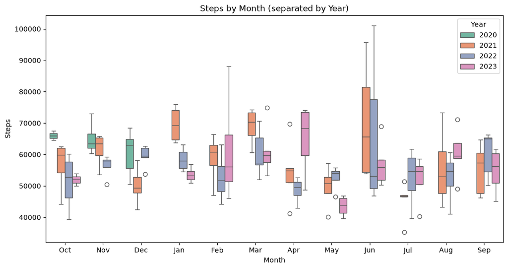

```python
# Your code here

#4. Make boxplot where there is for each month amount of steps separated by year
# Boxplot: steps by month, with a separate box per year
plt.figure(figsize=(12,6))
sns.boxplot(data=df, x="Month", y="Steps", hue="Year", palette="Set2")
plt.title("Steps by Month (separated by Year)")
plt.xlabel("Month")
plt.ylabel("Steps")
plt.legend(title="Year")
plt.show()
```

## Task: AI statement (mandatory)

I used AI (Gemini) to:

- **Learn how to read multiple sheets** from Excel—a technique I hadn't used before.
- **Guide me on using the `pd.DataFrame` constructor** to achieve a more professional coding style (even though I knew the simpler approach).
- **Correct syntax errors** in my Python code.
- **Help me get month_name**

## Task return

File > Save and Export Notebook As > HTML

Then take a look the produced HTML that it looks ok and readable

Return to Itslearning, only the html document is returned, *not the .ipynb